# Risk Factor Analysis

## Outcome Variable

**Outcome Variable:** wasted

## Predictor Variables

**Intervention Variable:** enwast

**Adjustment Set:**

unadjusted

## Stratifying Variables

The analysis was stratified on these variable(s):

- agecat
- studyid
- country

## Data Summary

| agecat | studyid | country | enwast | wasted | n_cell | n |
| --- | --- | --- | --- | --- | --- | --- |
| Birth | ki0047075b-MAL-ED | BANGLADESH | 0 | 0 | 201 | 241 |
| Birth | ki0047075b-MAL-ED | BANGLADESH | 0 | 1 | 0 | 241 |
| Birth | ki0047075b-MAL-ED | BANGLADESH | 1 | 0 | 0 | 241 |
| Birth | ki0047075b-MAL-ED | BANGLADESH | 1 | 1 | 40 | 241 |
| Birth | ki0047075b-MAL-ED | BRAZIL | 0 | 0 | 177 | 183 |
| Birth | ki0047075b-MAL-ED | BRAZIL | 0 | 1 | 0 | 183 |
| Birth | ki0047075b-MAL-ED | BRAZIL | 1 | 0 | 0 | 183 |
| Birth | ki0047075b-MAL-ED | BRAZIL | 1 | 1 | 6 | 183 |
| Birth | ki0047075b-MAL-ED | INDIA | 0 | 0 | 170 | 203 |
| Birth | ki0047075b-MAL-ED | INDIA | 0 | 1 | 0 | 203 |
| Birth | ki0047075b-MAL-ED | INDIA | 1 | 0 | 0 | 203 |
| Birth | ki0047075b-MAL-ED | INDIA | 1 | 1 | 33 | 203 |
| Birth | ki0047075b-MAL-ED | NEPAL | 0 | 0 | 148 | 168 |
| Birth | ki0047075b-MAL-ED | NEPAL | 0 | 1 | 0 | 168 |
| Birth | ki0047075b-MAL-ED | NEPAL | 1 | 0 | 0 | 168 |
| Birth | ki0047075b-MAL-ED | NEPAL | 1 | 1 | 20 | 168 |
| Birth | ki0047075b-MAL-ED | PERU | 0 | 0 | 273 | 279 |
| Birth | ki0047075b-MAL-ED | PERU | 0 | 1 | 0 | 279 |
| Birth | ki0047075b-MAL-ED | PERU | 1 | 0 | 0 | 279 |
| Birth | ki0047075b-MAL-ED | PERU | 1 | 1 | 6 | 279 |
| Birth | ki0047075b-MAL-ED | SOUTH AFRICA | 0 | 0 | 240 | 258 |
| Birth | ki0047075b-MAL-ED | SOUTH AFRICA | 0 | 1 | 0 | 258 |
| Birth | ki0047075b-MAL-ED | SOUTH AFRICA | 1 | 0 | 0 | 258 |
| Birth | ki0047075b-MAL-ED | SOUTH AFRICA | 1 | 1 | 18 | 258 |
| Birth | ki0047075b-MAL-ED | TANZANIA, UNITED REPUBLIC OF | 0 | 0 | 116 | 118 |
| Birth | ki0047075b-MAL-ED | TANZANIA, UNITED REPUBLIC OF | 0 | 1 | 0 | 118 |
| Birth | ki0047075b-MAL-ED | TANZANIA, UNITED REPUBLIC OF | 1 | 0 | 0 | 118 |
| Birth | ki0047075b-MAL-ED | TANZANIA, UNITED REPUBLIC OF | 1 | 1 | 2 | 118 |
| Birth | ki1000108-CMC-V-BCS-2002 | INDIA | 0 | 0 | 74 | 88 |
| Birth | ki1000108-CMC-V-BCS-2002 | INDIA | 0 | 1 | 0 | 88 |

[output cut: 314 more lines]

The following strata were considered:

- agecat: 24 months, studyid: ki0047075b-MAL-ED, country: BANGLADESH
- agecat: 24 months, studyid: ki0047075b-MAL-ED, country: BRAZIL
- agecat: 24 months, studyid: ki0047075b-MAL-ED, country: INDIA
- agecat: 24 months, studyid: ki0047075b-MAL-ED, country: NEPAL
- agecat: 24 months, studyid: ki0047075b-MAL-ED, country: PERU
- agecat: 24 months, studyid: ki0047075b-MAL-ED, country: SOUTH AFRICA
- agecat: 24 months, studyid: ki0047075b-MAL-ED, country: TANZANIA, UNITED REPUBLIC OF
- agecat: 24 months, studyid: ki1000108-CMC-V-BCS-2002, country: INDIA
- agecat: 24 months, studyid: ki1000108-IRC, country: INDIA
- agecat: 24 months, studyid: ki1017093-NIH-Birth, country: BANGLADESH
- agecat: 24 months, studyid: ki1017093b-PROVIDE, country: BANGLADESH
- agecat: 24 months, studyid: ki1017093c-NIH-Crypto, country: BANGLADESH
- agecat: 24 months, studyid: ki1066203-TanzaniaChild2, country: TANZANIA, UNITED REPUBLIC OF
- agecat: 24 months, studyid: ki1101329-Keneba, country: GAMBIA
- agecat: 24 months, studyid: ki1113344-GMS-Nepal, country: NEPAL
- agecat: 24 months, studyid: ki1114097-CMIN, country: BANGLADESH
- agecat: 24 months, studyid: ki1114097-CMIN, country: GUINEA-BISSAU
- agecat: 24 months, studyid: ki1114097-CMIN, country: PERU
- agecat: 24 months, studyid: ki1114097-CONTENT, country: PERU
- agecat: 24 months, studyid: ki1119695-PROBIT, country: BELARUS
- agecat: 24 months, studyid: ki1126311-ZVITAMBO, country: ZIMBABWE
- agecat: 24 months, studyid: ki1135781-COHORTS, country: GUATEMALA
- agecat: 24 months, studyid: ki1135781-COHORTS, country: INDIA
- agecat: 24 months, studyid: ki1135781-COHORTS, country: PHILIPPINES
- agecat: 24 months, studyid: ki1148112-LCNI-5, country: MALAWI
- agecat: 24 months, studyid: kiGH5241-JiVitA-3, country: BANGLADESH
- agecat: 24 months, studyid: kiGH5241-JiVitA-4, country: BANGLADESH
- agecat: 6 months, studyid: ki0047075b-MAL-ED, country: BANGLADESH
- agecat: 6 months, studyid: ki0047075b-MAL-ED, country: BRAZIL
- agecat: 6 months, studyid: ki0047075b-MAL-ED, country: INDIA
- agecat: 6 months, studyid: ki0047075b-MAL-ED, country: NEPAL
- agecat: 6 months, studyid: ki0047075b-MAL-ED, country: PERU
- agecat: 6 months, studyid: ki0047075b-MAL-ED, country: SOUTH AFRICA
- agecat: 6 months, studyid: ki0047075b-MAL-ED, country: TANZANIA, UNITED REPUBLIC OF
- agecat: 6 months, studyid: ki1000108-CMC-V-BCS-2002, country: INDIA
- agecat: 6 months, studyid: ki1000108-IRC, country: INDIA
- agecat: 6 months, studyid: ki1000109-EE, country: PAKISTAN
- agecat: 6 months, studyid: ki1000109-ResPak, country: PAKISTAN
- agecat: 6 months, studyid: ki1000304b-SAS-CompFeed, country: INDIA
- agecat: 6 months, studyid: ki1000304b-SAS-FoodSuppl, country: INDIA
- agecat: 6 months, studyid: ki1017093-NIH-Birth, country: BANGLADESH
- agecat: 6 months, studyid: ki1017093b-PROVIDE, country: BANGLADESH
- agecat: 6 months, studyid: ki1017093c-NIH-Crypto, country: BANGLADESH
- agecat: 6 months, studyid: ki1066203-TanzaniaChild2, country: TANZANIA, UNITED REPUBLIC OF
- agecat: 6 months, studyid: ki1101329-Keneba, country: GAMBIA
- agecat: 6 months, studyid: ki1112895-Guatemala BSC, country: GUATEMALA
- agecat: 6 months, studyid: ki1113344-GMS-Nepal, country: NEPAL
- agecat: 6 months, studyid: ki1114097-CMIN, country: BANGLADESH
- agecat: 6 months, studyid: ki1114097-CMIN, country: BRAZIL
- agecat: 6 months, studyid: ki1114097-CMIN, country: GUINEA-BISSAU
- agecat: 6 months, studyid: ki1114097-CMIN, country: PERU
- agecat: 6 months, studyid: ki1114097-CONTENT, country: PERU
- agecat: 6 months, studyid: ki1119695-PROBIT, country: BELARUS
- agecat: 6 months, studyid: ki1126311-ZVITAMBO, country: ZIMBABWE
- agecat: 6 months, studyid: ki1135781-COHORTS, country: GUATEMALA
- agecat: 6 months, studyid: ki1135781-COHORTS, country: INDIA
- agecat: 6 months, studyid: ki1135781-COHORTS, country: PHILIPPINES
- agecat: 6 months, studyid: ki1148112-LCNI-5, country: MALAWI
- agecat: 6 months, studyid: kiGH5241-JiVitA-3, country: BANGLADESH
- agecat: 6 months, studyid: kiGH5241-JiVitA-4, country: BANGLADESH
- agecat: Birth, studyid: ki0047075b-MAL-ED, country: BANGLADESH
- agecat: Birth, studyid: ki0047075b-MAL-ED, country: BRAZIL
- agecat: Birth, studyid: ki0047075b-MAL-ED, country: INDIA
- agecat: Birth, studyid: ki0047075b-MAL-ED, country: NEPAL
- agecat: Birth, studyid: ki0047075b-MAL-ED, country: PERU
- agecat: Birth, studyid: ki0047075b-MAL-ED, country: SOUTH AFRICA
- agecat: Birth, studyid: ki0047075b-MAL-ED, country: TANZANIA, UNITED REPUBLIC OF
- agecat: Birth, studyid: ki1000108-CMC-V-BCS-2002, country: INDIA
- agecat: Birth, studyid: ki1000108-IRC, country: INDIA
- agecat: Birth, studyid: ki1000109-EE, country: PAKISTAN
- agecat: Birth, studyid: ki1000109-ResPak, country: PAKISTAN
- agecat: Birth, studyid: ki1000304b-SAS-CompFeed, country: INDIA
- agecat: Birth, studyid: ki1017093-NIH-Birth, country: BANGLADESH
- agecat: Birth, studyid: ki1017093c-NIH-Crypto, country: BANGLADESH
- agecat: Birth, studyid: ki1101329-Keneba, country: GAMBIA
- agecat: Birth, studyid: ki1114097-CMIN, country: BANGLADESH
- agecat: Birth, studyid: ki1114097-CMIN, country: BRAZIL
- agecat: Birth, studyid: ki1114097-CMIN, country: PERU
- agecat: Birth, studyid: ki1114097-CONTENT, country: PERU
- agecat: Birth, studyid: ki1119695-PROBIT, country: BELARUS
- agecat: Birth, studyid: ki1126311-ZVITAMBO, country: ZIMBABWE
- agecat: Birth, studyid: ki1135781-COHORTS, country: GUATEMALA
- agecat: Birth, studyid: ki1135781-COHORTS, country: INDIA
- agecat: Birth, studyid: ki1135781-COHORTS, country: PHILIPPINES
- agecat: Birth, studyid: kiGH5241-JiVitA-3, country: BANGLADESH
- agecat: Birth, studyid: kiGH5241-JiVitA-4, country: BANGLADESH

### Dropped Strata

Some strata were dropped due to rare outcomes:

- agecat: Birth, studyid: ki0047075b-MAL-ED, country: BANGLADESH
- agecat: Birth, studyid: ki0047075b-MAL-ED, country: BRAZIL
- agecat: Birth, studyid: ki0047075b-MAL-ED, country: INDIA
- agecat: Birth, studyid: ki0047075b-MAL-ED, country: NEPAL
- agecat: Birth, studyid: ki0047075b-MAL-ED, country: PERU
- agecat: Birth, studyid: ki0047075b-MAL-ED, country: SOUTH AFRICA
- agecat: Birth, studyid: ki0047075b-MAL-ED, country: TANZANIA, UNITED REPUBLIC OF
- agecat: Birth, studyid: ki1000108-CMC-V-BCS-2002, country: INDIA
- agecat: Birth, studyid: ki1000108-IRC, country: INDIA
- agecat: Birth, studyid: ki1000109-EE, country: PAKISTAN
- agecat: Birth, studyid: ki1000109-ResPak, country: PAKISTAN
- agecat: Birth, studyid: ki1000304b-SAS-CompFeed, country: INDIA
- agecat: Birth, studyid: ki1017093-NIH-Birth, country: BANGLADESH
- agecat: Birth, studyid: ki1017093c-NIH-Crypto, country: BANGLADESH
- agecat: Birth, studyid: ki1101329-Keneba, country: GAMBIA
- agecat: Birth, studyid: ki1114097-CMIN, country: BANGLADESH
- agecat: Birth, studyid: ki1114097-CMIN, country: BRAZIL
- agecat: Birth, studyid: ki1114097-CMIN, country: PERU
- agecat: Birth, studyid: ki1114097-CONTENT, country: PERU
- agecat: Birth, studyid: ki1119695-PROBIT, country: BELARUS
- agecat: Birth, studyid: ki1126311-ZVITAMBO, country: ZIMBABWE
- agecat: Birth, studyid: ki1135781-COHORTS, country: GUATEMALA
- agecat: Birth, studyid: ki1135781-COHORTS, country: INDIA
- agecat: Birth, studyid: ki1135781-COHORTS, country: PHILIPPINES
- agecat: Birth, studyid: kiGH5241-JiVitA-3, country: BANGLADESH
- agecat: Birth, studyid: kiGH5241-JiVitA-4, country: BANGLADESH
- agecat: 6 months, studyid: ki0047075b-MAL-ED, country: BANGLADESH
- agecat: 6 months, studyid: ki0047075b-MAL-ED, country: BRAZIL
- agecat: 6 months, studyid: ki0047075b-MAL-ED, country: NEPAL
- agecat: 6 months, studyid: ki0047075b-MAL-ED, country: PERU
- agecat: 6 months, studyid: ki0047075b-MAL-ED, country: SOUTH AFRICA
- agecat: 6 months, studyid: ki0047075b-MAL-ED, country: TANZANIA, UNITED REPUBLIC OF
- agecat: 6 months, studyid: ki1112895-Guatemala BSC, country: GUATEMALA
- agecat: 6 months, studyid: ki1114097-CMIN, country: BRAZIL
- agecat: 6 months, studyid: ki1114097-CMIN, country: PERU
- agecat: 6 months, studyid: ki1114097-CONTENT, country: PERU
- agecat: 6 months, studyid: ki1148112-LCNI-5, country: MALAWI
- agecat: 24 months, studyid: ki0047075b-MAL-ED, country: BRAZIL
- agecat: 24 months, studyid: ki0047075b-MAL-ED, country: NEPAL
- agecat: 24 months, studyid: ki0047075b-MAL-ED, country: PERU
- agecat: 24 months, studyid: ki0047075b-MAL-ED, country: SOUTH AFRICA
- agecat: 24 months, studyid: ki0047075b-MAL-ED, country: TANZANIA, UNITED REPUBLIC OF
- agecat: 24 months, studyid: ki1066203-TanzaniaChild2, country: TANZANIA, UNITED REPUBLIC OF
- agecat: 24 months, studyid: ki1114097-CMIN, country: BANGLADESH
- agecat: 24 months, studyid: ki1114097-CMIN, country: PERU
- agecat: 24 months, studyid: ki1114097-CONTENT, country: PERU
- agecat: 24 months, studyid: ki1148112-LCNI-5, country: MALAWI

## Methods Detail

We’re interested in the causal parameters $E[Y_a]$ for all values of $a \in \mathcal{A}$. These parameters represent the mean outcome if, possibly contrary to fact, we intervened to set all units to have $A=a$. Under the randomization and positivity assumptions, these are identified by the statistical parameters $\psi_a=E_W[E_{Y|A,W}(Y|A=a,W)]$. In addition, we’re interested in the mean of $Y$, $E[Y]$ under no intervention (the observed mean). We will estimate these parameters by using SuperLearner to fit the relevant likelihood factors – $E_{Y|A,W}(Y|A=a,W)$ and $p(A=a|W)$, and then updating our likelihood fit using a joint TMLE.

For unadjusted analyses ($W=\{\}$), initial likelihoods were estimated using Lrnr_glm to estimate the simple $E(Y|A)$ and Lrnr_mean to estimate $p(A)$. For adjusted analyses, a small library containing Lrnr_glmnet, Lrnr_xgboost, and Lrnr_mean was used.

Having estimated these parameters, we will then use the delta method to estimate relative risks and attributable risks relative to a prespecified baseline level of $A$.

# Results Detail

## Results Plots

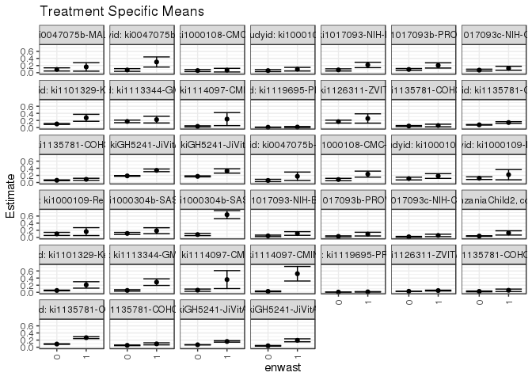

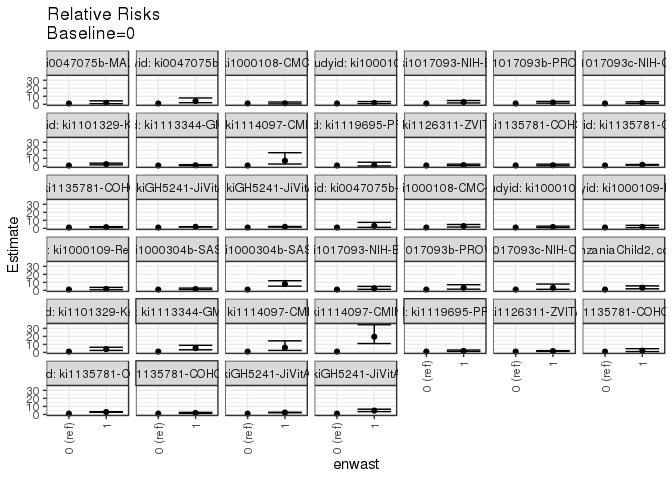

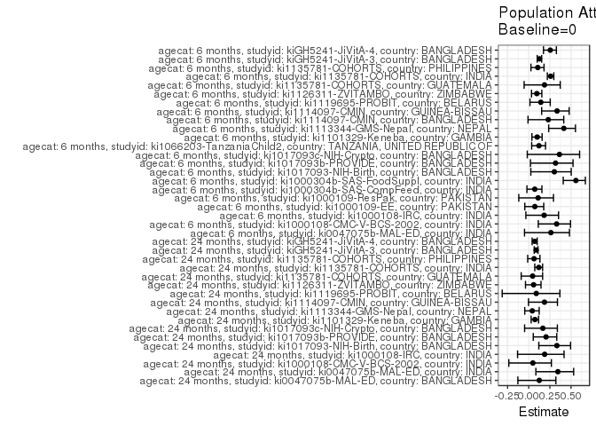

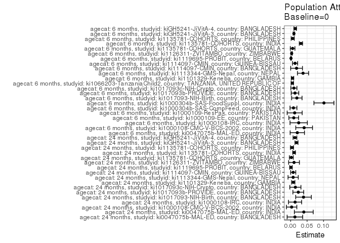

## Results Table

### Parameter: TSM

| agecat | studyid | country | intervention_level | baseline_level | estimate | ci_lower | ci_upper |
| --- | --- | --- | --- | --- | --- | --- | --- |
| 6 months | ki0047075b-MAL-ED | INDIA | 0 | NA | 0.0569948 | 0.0242171 | 0.0897725 |
| 6 months | ki0047075b-MAL-ED | INDIA | 1 | NA | 0.1750000 | 0.0569956 | 0.2930044 |
| 6 months | ki1000108-CMC-V-BCS-2002 | INDIA | 0 | NA | 0.0833333 | 0.0499475 | 0.1167191 |
| 6 months | ki1000108-CMC-V-BCS-2002 | INDIA | 1 | NA | 0.2346939 | 0.1506697 | 0.3187180 |
| 6 months | ki1000108-IRC | INDIA | 0 | NA | 0.1102362 | 0.0716712 | 0.1488013 |
| 6 months | ki1000108-IRC | INDIA | 1 | NA | 0.1818182 | 0.1159360 | 0.2477004 |
| 6 months | ki1000109-EE | PAKISTAN | 0 | NA | 0.1216216 | 0.0843300 | 0.1589133 |
| 6 months | ki1000109-EE | PAKISTAN | 1 | NA | 0.2187500 | 0.0752985 | 0.3622015 |
| 6 months | ki1000109-ResPak | PAKISTAN | 0 | NA | 0.0983607 | 0.0551180 | 0.1416033 |
| 6 months | ki1000109-ResPak | PAKISTAN | 1 | NA | 0.1627907 | 0.0522025 | 0.2733789 |
| 6 months | ki1000304b-SAS-CompFeed | INDIA | 0 | NA | 0.1120448 | 0.0831124 | 0.1409772 |
| 6 months | ki1000304b-SAS-CompFeed | INDIA | 1 | NA | 0.1870504 | 0.1027075 | 0.2713932 |
| 6 months | ki1000304b-SAS-FoodSuppl | INDIA | 0 | NA | 0.0803859 | 0.0501284 | 0.1106433 |
| 6 months | ki1000304b-SAS-FoodSuppl | INDIA | 1 | NA | 0.6376812 | 0.5241166 | 0.7512458 |
| 6 months | ki1017093-NIH-Birth | BANGLADESH | 0 | NA | 0.0434783 | 0.0226222 | 0.0643343 |
| 6 months | ki1017093-NIH-Birth | BANGLADESH | 1 | NA | 0.1103448 | 0.0592973 | 0.1613923 |
| 6 months | ki1017093b-PROVIDE | BANGLADESH | 0 | NA | 0.0285088 | 0.0132207 | 0.0437968 |
| 6 months | ki1017093b-PROVIDE | BANGLADESH | 1 | NA | 0.0924370 | 0.0403518 | 0.1445221 |
| 6 months | ki1017093c-NIH-Crypto | BANGLADESH | 0 | NA | 0.0174419 | 0.0061384 | 0.0287453 |
| 6 months | ki1017093c-NIH-Crypto | BANGLADESH | 1 | NA | 0.0561798 | 0.0223277 | 0.0900319 |
| 6 months | ki1066203-TanzaniaChild2 | TANZANIA, UNITED REPUBLIC OF | 0 | NA | 0.0378947 | 0.0293070 | 0.0464825 |
| 6 months | ki1066203-TanzaniaChild2 | TANZANIA, UNITED REPUBLIC OF | 1 | NA | 0.1260504 | 0.0664022 | 0.1856986 |
| 6 months | ki1101329-Keneba | GAMBIA | 0 | NA | 0.0519740 | 0.0422458 | 0.0617022 |
| 6 months | ki1101329-Keneba | GAMBIA | 1 | NA | 0.2077922 | 0.1171477 | 0.2984367 |
| 6 months | ki1113344-GMS-Nepal | NEPAL | 0 | NA | 0.0531915 | 0.0328848 | 0.0734982 |
| 6 months | ki1113344-GMS-Nepal | NEPAL | 1 | NA | 0.2857143 | 0.1928141 | 0.3786145 |
| 6 months | ki1114097-CMIN | BANGLADESH | 0 | NA | 0.0599078 | 0.0282641 | 0.0915515 |
| 6 months | ki1114097-CMIN | BANGLADESH | 1 | NA | 0.3571429 | 0.1056044 | 0.6086813 |
| 6 months | ki1114097-CMIN | GUINEA-BISSAU | 0 | NA | 0.0267640 | 0.0157244 | 0.0378036 |
| 6 months | ki1114097-CMIN | GUINEA-BISSAU | 1 | NA | 0.5217391 | 0.3174711 | 0.7260072 |
| 6 months | ki1119695-PROBIT | BELARUS | 0 | NA | 0.0070760 | 0.0058327 | 0.0083194 |
| 6 months | ki1119695-PROBIT | BELARUS | 1 | NA | 0.0131970 | 0.0071002 | 0.0192937 |
| 6 months | ki1126311-ZVITAMBO | ZIMBABWE | 0 | NA | 0.0292735 | 0.0252042 | 0.0333428 |
| 6 months | ki1126311-ZVITAMBO | ZIMBABWE | 1 | NA | 0.0491400 | 0.0370147 | 0.0612654 |
| 6 months | ki1135781-COHORTS | GUATEMALA | 0 | NA | 0.0260989 | 0.0145114 | 0.0376864 |
| 6 months | ki1135781-COHORTS | GUATEMALA | 1 | NA | 0.0568182 | 0.0225987 | 0.0910377 |
| 6 months | ki1135781-COHORTS | INDIA | 0 | NA | 0.0895522 | 0.0819075 | 0.0971970 |
| 6 months | ki1135781-COHORTS | INDIA | 1 | NA | 0.2687225 | 0.2429310 | 0.2945140 |
| 6 months | ki1135781-COHORTS | PHILIPPINES | 0 | NA | 0.0534491 | 0.0440247 | 0.0628734 |
| 6 months | ki1135781-COHORTS | PHILIPPINES | 1 | NA | 0.0947631 | 0.0660909 | 0.1234353 |
| 6 months | kiGH5241-JiVitA-3 | BANGLADESH | 0 | NA | 0.0688892 | 0.0640083 | 0.0737702 |
| 6 months | kiGH5241-JiVitA-3 | BANGLADESH | 1 | NA | 0.1624382 | 0.1423077 | 0.1825687 |
| 6 months | kiGH5241-JiVitA-4 | BANGLADESH | 0 | NA | 0.0408685 | 0.0314966 | 0.0502403 |
| 6 months | kiGH5241-JiVitA-4 | BANGLADESH | 1 | NA | 0.1948718 | 0.1529618 | 0.2367818 |
| 24 months | ki0047075b-MAL-ED | BANGLADESH | 0 | NA | 0.0914634 | 0.0472347 | 0.1356921 |
| 24 months | ki0047075b-MAL-ED | BANGLADESH | 1 | NA | 0.1621622 | 0.0430969 | 0.2812274 |
| 24 months | ki0047075b-MAL-ED | INDIA | 0 | NA | 0.0760870 | 0.0376914 | 0.1144826 |
| 24 months | ki0047075b-MAL-ED | INDIA | 1 | NA | 0.3000000 | 0.1576691 | 0.4423309 |
| 24 months | ki1000108-CMC-V-BCS-2002 | INDIA | 0 | NA | 0.0599251 | 0.0314166 | 0.0884336 |
| 24 months | ki1000108-CMC-V-BCS-2002 | INDIA | 1 | NA | 0.0714286 | 0.0203693 | 0.1224878 |
| 24 months | ki1000108-IRC | INDIA | 0 | NA | 0.0585938 | 0.0297864 | 0.0874011 |
| 24 months | ki1000108-IRC | INDIA | 1 | NA | 0.0984848 | 0.0475878 | 0.1493819 |
| 24 months | ki1017093-NIH-Birth | BANGLADESH | 0 | NA | 0.0784983 | 0.0476646 | 0.1093320 |
| 24 months | ki1017093-NIH-Birth | BANGLADESH | 1 | NA | 0.2173913 | 0.1419124 | 0.2928702 |
| 24 months | ki1017093b-PROVIDE | BANGLADESH | 0 | NA | 0.0907080 | 0.0642087 | 0.1172073 |
| 24 months | ki1017093b-PROVIDE | BANGLADESH | 1 | NA | 0.2033898 | 0.1306996 | 0.2760800 |
| 24 months | ki1017093c-NIH-Crypto | BANGLADESH | 0 | NA | 0.0716253 | 0.0450717 | 0.0981790 |
| 24 months | ki1017093c-NIH-Crypto | BANGLADESH | 1 | NA | 0.1240876 | 0.0688268 | 0.1793484 |
| 24 months | ki1101329-Keneba | GAMBIA | 0 | NA | 0.1020159 | 0.0873497 | 0.1166821 |
| 24 months | ki1101329-Keneba | GAMBIA | 1 | NA | 0.2750000 | 0.1771265 | 0.3728735 |
| 24 months | ki1113344-GMS-Nepal | NEPAL | 0 | NA | 0.1738095 | 0.1375319 | 0.2100871 |
| 24 months | ki1113344-GMS-Nepal | NEPAL | 1 | NA | 0.2236842 | 0.1299029 | 0.3174655 |
| 24 months | ki1114097-CMIN | GUINEA-BISSAU | 0 | NA | 0.0341556 | 0.0186344 | 0.0496767 |
| 24 months | ki1114097-CMIN | GUINEA-BISSAU | 1 | NA | 0.2380952 | 0.0557641 | 0.4204263 |
| 24 months | ki1119695-PROBIT | BELARUS | 0 | NA | 0.0101010 | 0.0050217 | 0.0151804 |
| 24 months | ki1119695-PROBIT | BELARUS | 1 | NA | 0.0144605 | -0.0034794 | 0.0324005 |
| 24 months | ki1126311-ZVITAMBO | ZIMBABWE | 0 | NA | 0.1682243 | 0.1272473 | 0.2092013 |
| 24 months | ki1126311-ZVITAMBO | ZIMBABWE | 1 | NA | 0.2558140 | 0.1252227 | 0.3864052 |
| 24 months | ki1135781-COHORTS | GUATEMALA | 0 | NA | 0.0441176 | 0.0305739 | 0.0576614 |
| 24 months | ki1135781-COHORTS | GUATEMALA | 1 | NA | 0.0584416 | 0.0213751 | 0.0955081 |
| 24 months | ki1135781-COHORTS | INDIA | 0 | NA | 0.0776538 | 0.0695698 | 0.0857378 |
| 24 months | ki1135781-COHORTS | INDIA | 1 | NA | 0.1423313 | 0.1183417 | 0.1663209 |
| 24 months | ki1135781-COHORTS | PHILIPPINES | 0 | NA | 0.0618090 | 0.0512266 | 0.0723915 |
| 24 months | ki1135781-COHORTS | PHILIPPINES | 1 | NA | 0.0888889 | 0.0594854 | 0.1182924 |
| 24 months | kiGH5241-JiVitA-3 | BANGLADESH | 0 | NA | 0.1855719 | 0.1747608 | 0.1963829 |
| 24 months | kiGH5241-JiVitA-3 | BANGLADESH | 1 | NA | 0.3414634 | 0.3046737 | 0.3782531 |
| 24 months | kiGH5241-JiVitA-4 | BANGLADESH | 0 | NA | 0.1727023 | 0.1584128 | 0.1869919 |
| 24 months | kiGH5241-JiVitA-4 | BANGLADESH | 1 | NA | 0.3241379 | 0.2635295 | 0.3847464 |

### Parameter: E(Y)

| agecat | studyid | country | intervention_level | baseline_level | estimate | ci_lower | ci_upper |
| --- | --- | --- | --- | --- | --- | --- | --- |
| 6 months | ki0047075b-MAL-ED | INDIA | NA | NA | 0.0772532 | 0.0428971 | 0.1116093 |
| 6 months | ki1000108-CMC-V-BCS-2002 | INDIA | NA | NA | 0.1243094 | 0.0902747 | 0.1583441 |
| 6 months | ki1000108-IRC | INDIA | NA | NA | 0.1347150 | 0.1006110 | 0.1688190 |
| 6 months | ki1000109-EE | PAKISTAN | NA | NA | 0.1310976 | 0.0945164 | 0.1676787 |
| 6 months | ki1000109-ResPak | PAKISTAN | NA | NA | 0.1106195 | 0.0696353 | 0.1516037 |
| 6 months | ki1000304b-SAS-CompFeed | INDIA | NA | NA | 0.1206612 | 0.0934553 | 0.1478670 |
| 6 months | ki1000304b-SAS-FoodSuppl | INDIA | NA | NA | 0.1815789 | 0.1427684 | 0.2203895 |
| 6 months | ki1017093-NIH-Birth | BANGLADESH | NA | NA | 0.0623782 | 0.0414301 | 0.0833262 |
| 6 months | ki1017093b-PROVIDE | BANGLADESH | NA | NA | 0.0417391 | 0.0253783 | 0.0581000 |
| 6 months | ki1017093c-NIH-Crypto | BANGLADESH | NA | NA | 0.0273775 | 0.0152282 | 0.0395268 |
| 6 months | ki1066203-TanzaniaChild2 | TANZANIA, UNITED REPUBLIC OF | NA | NA | 0.0430906 | 0.0342310 | 0.0519502 |
| 6 months | ki1101329-Keneba | GAMBIA | NA | NA | 0.0577478 | 0.0477160 | 0.0677797 |
| 6 months | ki1113344-GMS-Nepal | NEPAL | NA | NA | 0.0909091 | 0.0670990 | 0.1147192 |
| 6 months | ki1114097-CMIN | BANGLADESH | NA | NA | 0.0779221 | 0.0432805 | 0.1125637 |
| 6 months | ki1114097-CMIN | GUINEA-BISSAU | NA | NA | 0.0402367 | 0.0269789 | 0.0534944 |
| 6 months | ki1119695-PROBIT | BELARUS | NA | NA | 0.0082540 | 0.0066043 | 0.0099037 |
| 6 months | ki1126311-ZVITAMBO | ZIMBABWE | NA | NA | 0.0323778 | 0.0284530 | 0.0363026 |
| 6 months | ki1135781-COHORTS | GUATEMALA | NA | NA | 0.0320796 | 0.0205865 | 0.0435728 |
| 6 months | ki1135781-COHORTS | INDIA | NA | NA | 0.1208622 | 0.1129342 | 0.1287902 |
| 6 months | ki1135781-COHORTS | PHILIPPINES | NA | NA | 0.0598456 | 0.0507087 | 0.0689824 |
| 6 months | kiGH5241-JiVitA-3 | BANGLADESH | NA | NA | 0.0789037 | 0.0738012 | 0.0840062 |
| 6 months | kiGH5241-JiVitA-4 | BANGLADESH | NA | NA | 0.0548200 | 0.0454626 | 0.0641774 |
| 24 months | ki0047075b-MAL-ED | BANGLADESH | NA | NA | 0.1044776 | 0.0620857 | 0.1468695 |
| 24 months | ki0047075b-MAL-ED | INDIA | NA | NA | 0.1160714 | 0.0740310 | 0.1581118 |
| 24 months | ki1000108-CMC-V-BCS-2002 | INDIA | NA | NA | 0.0630137 | 0.0380516 | 0.0879758 |
| 24 months | ki1000108-IRC | INDIA | NA | NA | 0.0721649 | 0.0463845 | 0.0979454 |
| 24 months | ki1017093-NIH-Birth | BANGLADESH | NA | NA | 0.1176471 | 0.0863457 | 0.1489484 |
| 24 months | ki1017093b-PROVIDE | BANGLADESH | NA | NA | 0.1140351 | 0.0879183 | 0.1401519 |
| 24 months | ki1017093c-NIH-Crypto | BANGLADESH | NA | NA | 0.0860000 | 0.0614008 | 0.1105992 |
| 24 months | ki1101329-Keneba | GAMBIA | NA | NA | 0.1100757 | 0.0952672 | 0.1248842 |
| 24 months | ki1113344-GMS-Nepal | NEPAL | NA | NA | 0.1814516 | 0.1475010 | 0.2154023 |
| 24 months | ki1114097-CMIN | GUINEA-BISSAU | NA | NA | 0.0419708 | 0.0251666 | 0.0587750 |
| 24 months | ki1119695-PROBIT | BELARUS | NA | NA | 0.0110887 | 0.0050591 | 0.0171183 |
| 24 months | ki1126311-ZVITAMBO | ZIMBABWE | NA | NA | 0.1785714 | 0.1391724 | 0.2179705 |
| 24 months | ki1135781-COHORTS | GUATEMALA | NA | NA | 0.0462428 | 0.0334608 | 0.0590248 |
| 24 months | ki1135781-COHORTS | INDIA | NA | NA | 0.0881417 | 0.0803031 | 0.0959802 |
| 24 months | ki1135781-COHORTS | PHILIPPINES | NA | NA | 0.0659574 | 0.0559200 | 0.0759949 |
| 24 months | kiGH5241-JiVitA-3 | BANGLADESH | NA | NA | 0.2033521 | 0.1926606 | 0.2140436 |
| 24 months | kiGH5241-JiVitA-4 | BANGLADESH | NA | NA | 0.1858132 | 0.1713776 | 0.2002488 |

### Parameter: RR

| agecat | studyid | country | intervention_level | baseline_level | estimate | ci_lower | ci_upper |
| --- | --- | --- | --- | --- | --- | --- | --- |
| 6 months | ki0047075b-MAL-ED | INDIA | 0 | 0 | 1.000000 | 1.0000000 | 1.000000 |
| 6 months | ki0047075b-MAL-ED | INDIA | 1 | 0 | 3.070454 | 1.2656407 | 7.448947 |
| 6 months | ki1000108-CMC-V-BCS-2002 | INDIA | 0 | 0 | 1.000000 | 1.0000000 | 1.000000 |
| 6 months | ki1000108-CMC-V-BCS-2002 | INDIA | 1 | 0 | 2.816327 | 1.6456645 | 4.819752 |
| 6 months | ki1000108-IRC | INDIA | 0 | 0 | 1.000000 | 1.0000000 | 1.000000 |
| 6 months | ki1000108-IRC | INDIA | 1 | 0 | 1.649351 | 0.9967134 | 2.729328 |
| 6 months | ki1000109-EE | PAKISTAN | 0 | 0 | 1.000000 | 1.0000000 | 1.000000 |
| 6 months | ki1000109-EE | PAKISTAN | 1 | 0 | 1.798611 | 0.8720522 | 3.709643 |
| 6 months | ki1000109-ResPak | PAKISTAN | 0 | 0 | 1.000000 | 1.0000000 | 1.000000 |
| 6 months | ki1000109-ResPak | PAKISTAN | 1 | 0 | 1.655039 | 0.7368653 | 3.717305 |
| 6 months | ki1000304b-SAS-CompFeed | INDIA | 0 | 0 | 1.000000 | 1.0000000 | 1.000000 |
| 6 months | ki1000304b-SAS-CompFeed | INDIA | 1 | 0 | 1.669425 | 0.9836558 | 2.833286 |
| 6 months | ki1000304b-SAS-FoodSuppl | INDIA | 0 | 0 | 1.000000 | 1.0000000 | 1.000000 |
| 6 months | ki1000304b-SAS-FoodSuppl | INDIA | 1 | 0 | 7.932754 | 5.2309486 | 12.030051 |
| 6 months | ki1017093-NIH-Birth | BANGLADESH | 0 | 0 | 1.000000 | 1.0000000 | 1.000000 |
| 6 months | ki1017093-NIH-Birth | BANGLADESH | 1 | 0 | 2.537931 | 1.3033378 | 4.941999 |
| 6 months | ki1017093b-PROVIDE | BANGLADESH | 0 | 0 | 1.000000 | 1.0000000 | 1.000000 |
| 6 months | ki1017093b-PROVIDE | BANGLADESH | 1 | 0 | 3.242405 | 1.4895209 | 7.058100 |
| 6 months | ki1017093c-NIH-Crypto | BANGLADESH | 0 | 0 | 1.000000 | 1.0000000 | 1.000000 |
| 6 months | ki1017093c-NIH-Crypto | BANGLADESH | 1 | 0 | 3.220974 | 1.3294526 | 7.803716 |
| 6 months | ki1066203-TanzaniaChild2 | TANZANIA, UNITED REPUBLIC OF | 0 | 0 | 1.000000 | 1.0000000 | 1.000000 |
| 6 months | ki1066203-TanzaniaChild2 | TANZANIA, UNITED REPUBLIC OF | 1 | 0 | 3.326331 | 1.9683476 | 5.621200 |
| 6 months | ki1101329-Keneba | GAMBIA | 0 | 0 | 1.000000 | 1.0000000 | 1.000000 |
| 6 months | ki1101329-Keneba | GAMBIA | 1 | 0 | 3.998002 | 2.4870757 | 6.426833 |
| 6 months | ki1113344-GMS-Nepal | NEPAL | 0 | 0 | 1.000000 | 1.0000000 | 1.000000 |
| 6 months | ki1113344-GMS-Nepal | NEPAL | 1 | 0 | 5.371429 | 3.2531644 | 8.868978 |
| 6 months | ki1114097-CMIN | BANGLADESH | 0 | 0 | 1.000000 | 1.0000000 | 1.000000 |
| 6 months | ki1114097-CMIN | BANGLADESH | 1 | 0 | 5.961538 | 2.4718296 | 14.377990 |
| 6 months | ki1114097-CMIN | GUINEA-BISSAU | 0 | 0 | 1.000000 | 1.0000000 | 1.000000 |
| 6 months | ki1114097-CMIN | GUINEA-BISSAU | 1 | 0 | 19.494071 | 11.0387037 | 34.426036 |
| 6 months | ki1119695-PROBIT | BELARUS | 0 | 0 | 1.000000 | 1.0000000 | 1.000000 |
| 6 months | ki1119695-PROBIT | BELARUS | 1 | 0 | 1.865024 | 1.1785842 | 2.951266 |
| 6 months | ki1126311-ZVITAMBO | ZIMBABWE | 0 | 0 | 1.000000 | 1.0000000 | 1.000000 |
| 6 months | ki1126311-ZVITAMBO | ZIMBABWE | 1 | 0 | 1.678655 | 1.2646299 | 2.228226 |
| 6 months | ki1135781-COHORTS | GUATEMALA | 0 | 0 | 1.000000 | 1.0000000 | 1.000000 |
| 6 months | ki1135781-COHORTS | GUATEMALA | 1 | 0 | 2.177033 | 1.0301824 | 4.600617 |
| 6 months | ki1135781-COHORTS | INDIA | 0 | 0 | 1.000000 | 1.0000000 | 1.000000 |
| 6 months | ki1135781-COHORTS | INDIA | 1 | 0 | 3.000734 | 2.6390195 | 3.412027 |
| 6 months | ki1135781-COHORTS | PHILIPPINES | 0 | 0 | 1.000000 | 1.0000000 | 1.000000 |
| 6 months | ki1135781-COHORTS | PHILIPPINES | 1 | 0 | 1.772961 | 1.2491403 | 2.516443 |
| 6 months | kiGH5241-JiVitA-3 | BANGLADESH | 0 | 0 | 1.000000 | 1.0000000 | 1.000000 |
| 6 months | kiGH5241-JiVitA-3 | BANGLADESH | 1 | 0 | 2.357962 | 2.0572743 | 2.702598 |
| 6 months | kiGH5241-JiVitA-4 | BANGLADESH | 0 | 0 | 1.000000 | 1.0000000 | 1.000000 |
| 6 months | kiGH5241-JiVitA-4 | BANGLADESH | 1 | 0 | 4.768269 | 3.4923008 | 6.510433 |
| 24 months | ki0047075b-MAL-ED | BANGLADESH | 0 | 0 | 1.000000 | 1.0000000 | 1.000000 |
| 24 months | ki0047075b-MAL-ED | BANGLADESH | 1 | 0 | 1.772973 | 0.7360098 | 4.270912 |
| 24 months | ki0047075b-MAL-ED | INDIA | 0 | 0 | 1.000000 | 1.0000000 | 1.000000 |
| 24 months | ki0047075b-MAL-ED | INDIA | 1 | 0 | 3.942857 | 1.9724443 | 7.881653 |
| 24 months | ki1000108-CMC-V-BCS-2002 | INDIA | 0 | 0 | 1.000000 | 1.0000000 | 1.000000 |
| 24 months | ki1000108-CMC-V-BCS-2002 | INDIA | 1 | 0 | 1.191964 | 0.5050681 | 2.813044 |
| 24 months | ki1000108-IRC | INDIA | 0 | 0 | 1.000000 | 1.0000000 | 1.000000 |
| 24 months | ki1000108-IRC | INDIA | 1 | 0 | 1.680808 | 0.8236365 | 3.430051 |
| 24 months | ki1017093-NIH-Birth | BANGLADESH | 0 | 0 | 1.000000 | 1.0000000 | 1.000000 |
| 24 months | ki1017093-NIH-Birth | BANGLADESH | 1 | 0 | 2.769376 | 1.6394699 | 4.678003 |
| 24 months | ki1017093b-PROVIDE | BANGLADESH | 0 | 0 | 1.000000 | 1.0000000 | 1.000000 |
| 24 months | ki1017093b-PROVIDE | BANGLADESH | 1 | 0 | 2.242249 | 1.4132311 | 3.557578 |
| 24 months | ki1017093c-NIH-Crypto | BANGLADESH | 0 | 0 | 1.000000 | 1.0000000 | 1.000000 |
| 24 months | ki1017093c-NIH-Crypto | BANGLADESH | 1 | 0 | 1.732454 | 0.9705288 | 3.092537 |
| 24 months | ki1101329-Keneba | GAMBIA | 0 | 0 | 1.000000 | 1.0000000 | 1.000000 |
| 24 months | ki1101329-Keneba | GAMBIA | 1 | 0 | 2.695659 | 1.8363861 | 3.956998 |
| 24 months | ki1113344-GMS-Nepal | NEPAL | 0 | 0 | 1.000000 | 1.0000000 | 1.000000 |
| 24 months | ki1113344-GMS-Nepal | NEPAL | 1 | 0 | 1.286950 | 0.8056841 | 2.055695 |
| 24 months | ki1114097-CMIN | GUINEA-BISSAU | 0 | 0 | 1.000000 | 1.0000000 | 1.000000 |
| 24 months | ki1114097-CMIN | GUINEA-BISSAU | 1 | 0 | 6.970899 | 2.8612942 | 16.983028 |
| 24 months | ki1119695-PROBIT | BELARUS | 0 | 0 | 1.000000 | 1.0000000 | 1.000000 |
| 24 months | ki1119695-PROBIT | BELARUS | 1 | 0 | 1.431591 | 0.4040341 | 5.072473 |
| 24 months | ki1126311-ZVITAMBO | ZIMBABWE | 0 | 0 | 1.000000 | 1.0000000 | 1.000000 |
| 24 months | ki1126311-ZVITAMBO | ZIMBABWE | 1 | 0 | 1.520672 | 0.8637450 | 2.677229 |
| 24 months | ki1135781-COHORTS | GUATEMALA | 0 | 0 | 1.000000 | 1.0000000 | 1.000000 |
| 24 months | ki1135781-COHORTS | GUATEMALA | 1 | 0 | 1.324675 | 0.6547698 | 2.679972 |
| 24 months | ki1135781-COHORTS | INDIA | 0 | 0 | 1.000000 | 1.0000000 | 1.000000 |
| 24 months | ki1135781-COHORTS | INDIA | 1 | 0 | 1.832896 | 1.5034944 | 2.234467 |
| 24 months | ki1135781-COHORTS | PHILIPPINES | 0 | 0 | 1.000000 | 1.0000000 | 1.000000 |
| 24 months | ki1135781-COHORTS | PHILIPPINES | 1 | 0 | 1.438121 | 0.9909077 | 2.087169 |
| 24 months | kiGH5241-JiVitA-3 | BANGLADESH | 0 | 0 | 1.000000 | 1.0000000 | 1.000000 |
| 24 months | kiGH5241-JiVitA-3 | BANGLADESH | 1 | 0 | 1.840060 | 1.6309545 | 2.075976 |
| 24 months | kiGH5241-JiVitA-4 | BANGLADESH | 0 | 0 | 1.000000 | 1.0000000 | 1.000000 |
| 24 months | kiGH5241-JiVitA-4 | BANGLADESH | 1 | 0 | 1.876859 | 1.5360779 | 2.293243 |

### Parameter: PAR

| agecat | studyid | country | intervention_level | baseline_level | estimate | ci_lower | ci_upper |
| --- | --- | --- | --- | --- | --- | --- | --- |
| 6 months | ki0047075b-MAL-ED | INDIA | 0 | NA | 0.0202584 | -0.0015326 | 0.0420494 |
| 6 months | ki1000108-CMC-V-BCS-2002 | INDIA | 0 | NA | 0.0409761 | 0.0155352 | 0.0664170 |
| 6 months | ki1000108-IRC | INDIA | 0 | NA | 0.0244788 | -0.0018464 | 0.0508040 |
| 6 months | ki1000109-EE | PAKISTAN | 0 | NA | 0.0094759 | -0.0053180 | 0.0242699 |
| 6 months | ki1000109-ResPak | PAKISTAN | 0 | NA | 0.0122588 | -0.0105741 | 0.0350917 |
| 6 months | ki1000304b-SAS-CompFeed | INDIA | 0 | NA | 0.0086163 | -0.0018965 | 0.0191292 |
| 6 months | ki1000304b-SAS-FoodSuppl | INDIA | 0 | NA | 0.1011931 | 0.0708086 | 0.1315776 |
| 6 months | ki1017093-NIH-Birth | BANGLADESH | 0 | NA | 0.0188999 | 0.0030968 | 0.0347030 |
| 6 months | ki1017093b-PROVIDE | BANGLADESH | 0 | NA | 0.0132304 | 0.0017982 | 0.0246625 |
| 6 months | ki1017093c-NIH-Crypto | BANGLADESH | 0 | NA | 0.0099357 | 0.0006957 | 0.0191757 |
| 6 months | ki1066203-TanzaniaChild2 | TANZANIA, UNITED REPUBLIC OF | 0 | NA | 0.0051959 | 0.0015303 | 0.0088615 |
| 6 months | ki1101329-Keneba | GAMBIA | 0 | NA | 0.0057738 | 0.0021663 | 0.0093813 |
| 6 months | ki1113344-GMS-Nepal | NEPAL | 0 | NA | 0.0377176 | 0.0207371 | 0.0546981 |
| 6 months | ki1114097-CMIN | BANGLADESH | 0 | NA | 0.0180142 | 0.0001232 | 0.0359053 |
| 6 months | ki1114097-CMIN | GUINEA-BISSAU | 0 | NA | 0.0134727 | 0.0056926 | 0.0212528 |
| 6 months | ki1119695-PROBIT | BELARUS | 0 | NA | 0.0011779 | 0.0000531 | 0.0023027 |
| 6 months | ki1126311-ZVITAMBO | ZIMBABWE | 0 | NA | 0.0031043 | 0.0010994 | 0.0051092 |
| 6 months | ki1135781-COHORTS | GUATEMALA | 0 | NA | 0.0059807 | -0.0010977 | 0.0130591 |
| 6 months | ki1135781-COHORTS | INDIA | 0 | NA | 0.0313100 | 0.0263263 | 0.0362936 |
| 6 months | ki1135781-COHORTS | PHILIPPINES | 0 | NA | 0.0063965 | 0.0016883 | 0.0111047 |
| 6 months | kiGH5241-JiVitA-3 | BANGLADESH | 0 | NA | 0.0100145 | 0.0078207 | 0.0122083 |
| 6 months | kiGH5241-JiVitA-4 | BANGLADESH | 0 | NA | 0.0139515 | 0.0099897 | 0.0179133 |
| 24 months | ki0047075b-MAL-ED | BANGLADESH | 0 | NA | 0.0130142 | -0.0106730 | 0.0367013 |
| 24 months | ki0047075b-MAL-ED | INDIA | 0 | NA | 0.0399845 | 0.0113544 | 0.0686146 |
| 24 months | ki1000108-CMC-V-BCS-2002 | INDIA | 0 | NA | 0.0030886 | -0.0126213 | 0.0187985 |
| 24 months | ki1000108-IRC | INDIA | 0 | NA | 0.0135712 | -0.0064143 | 0.0335567 |
| 24 months | ki1017093-NIH-Birth | BANGLADESH | 0 | NA | 0.0391488 | 0.0153791 | 0.0629185 |
| 24 months | ki1017093b-PROVIDE | BANGLADESH | 0 | NA | 0.0233271 | 0.0068768 | 0.0397774 |
| 24 months | ki1017093c-NIH-Crypto | BANGLADESH | 0 | NA | 0.0143747 | -0.0025491 | 0.0312984 |
| 24 months | ki1101329-Keneba | GAMBIA | 0 | NA | 0.0080598 | 0.0031366 | 0.0129831 |
| 24 months | ki1113344-GMS-Nepal | NEPAL | 0 | NA | 0.0076421 | -0.0078464 | 0.0231305 |
| 24 months | ki1114097-CMIN | GUINEA-BISSAU | 0 | NA | 0.0078152 | 0.0000732 | 0.0155572 |
| 24 months | ki1119695-PROBIT | BELARUS | 0 | NA | 0.0009877 | -0.0029768 | 0.0049522 |
| 24 months | ki1126311-ZVITAMBO | ZIMBABWE | 0 | NA | 0.0103471 | -0.0060810 | 0.0267752 |
| 24 months | ki1135781-COHORTS | GUATEMALA | 0 | NA | 0.0021251 | -0.0037379 | 0.0079882 |
| 24 months | ki1135781-COHORTS | INDIA | 0 | NA | 0.0104879 | 0.0063303 | 0.0146455 |
| 24 months | ki1135781-COHORTS | PHILIPPINES | 0 | NA | 0.0041484 | -0.0006550 | 0.0089518 |
| 24 months | kiGH5241-JiVitA-3 | BANGLADESH | 0 | NA | 0.0177802 | 0.0131850 | 0.0223755 |
| 24 months | kiGH5241-JiVitA-4 | BANGLADESH | 0 | NA | 0.0131109 | 0.0074251 | 0.0187967 |

### Parameter: PAF

| agecat | studyid | country | intervention_level | baseline_level | estimate | ci_lower | ci_upper |
| --- | --- | --- | --- | --- | --- | --- | --- |
| 6 months | ki0047075b-MAL-ED | INDIA | 0 | NA | 0.2622337 | -0.0495942 | 0.4814195 |
| 6 months | ki1000108-CMC-V-BCS-2002 | INDIA | 0 | NA | 0.3296296 | 0.1128106 | 0.4934606 |
| 6 months | ki1000108-IRC | INDIA | 0 | NA | 0.1817081 | -0.0338484 | 0.3523212 |
| 6 months | ki1000109-EE | PAKISTAN | 0 | NA | 0.0722816 | -0.0462425 | 0.1773786 |
| 6 months | ki1000109-ResPak | PAKISTAN | 0 | NA | 0.1108197 | -0.1174781 | 0.2924768 |
| 6 months | ki1000304b-SAS-CompFeed | INDIA | 0 | NA | 0.0714094 | -0.0211428 | 0.1555730 |
| 6 months | ki1000304b-SAS-FoodSuppl | INDIA | 0 | NA | 0.5572953 | 0.4077485 | 0.6690807 |
| 6 months | ki1017093-NIH-Birth | BANGLADESH | 0 | NA | 0.3029891 | 0.0248179 | 0.5018118 |
| 6 months | ki1017093b-PROVIDE | BANGLADESH | 0 | NA | 0.3169773 | 0.0208909 | 0.5235261 |
| 6 months | ki1017093c-NIH-Crypto | BANGLADESH | 0 | NA | 0.3629131 | -0.0173110 | 0.6010269 |
| 6 months | ki1066203-TanzaniaChild2 | TANZANIA, UNITED REPUBLIC OF | 0 | NA | 0.1205808 | 0.0349948 | 0.1985761 |
| 6 months | ki1101329-Keneba | GAMBIA | 0 | NA | 0.0999833 | 0.0376356 | 0.1582918 |
| 6 months | ki1113344-GMS-Nepal | NEPAL | 0 | NA | 0.4148936 | 0.2355896 | 0.5521391 |
| 6 months | ki1114097-CMIN | BANGLADESH | 0 | NA | 0.2311828 | -0.0084996 | 0.4139017 |
| 6 months | ki1114097-CMIN | GUINEA-BISSAU | 0 | NA | 0.3348361 | 0.1527858 | 0.4777673 |
| 6 months | ki1119695-PROBIT | BELARUS | 0 | NA | 0.1427120 | 0.0145247 | 0.2542251 |
| 6 months | ki1126311-ZVITAMBO | ZIMBABWE | 0 | NA | 0.0958778 | 0.0328911 | 0.1547623 |
| 6 months | ki1135781-COHORTS | GUATEMALA | 0 | NA | 0.1864343 | -0.0542856 | 0.3721917 |
| 6 months | ki1135781-COHORTS | INDIA | 0 | NA | 0.2590550 | 0.2197006 | 0.2964246 |
| 6 months | ki1135781-COHORTS | PHILIPPINES | 0 | NA | 0.1068834 | 0.0262947 | 0.1808022 |
| 6 months | kiGH5241-JiVitA-3 | BANGLADESH | 0 | NA | 0.1269205 | 0.1001129 | 0.1529295 |
| 6 months | kiGH5241-JiVitA-4 | BANGLADESH | 0 | NA | 0.2544970 | 0.1742871 | 0.3269154 |
| 24 months | ki0047075b-MAL-ED | BANGLADESH | 0 | NA | 0.1245645 | -0.1283691 | 0.3208008 |
| 24 months | ki0047075b-MAL-ED | INDIA | 0 | NA | 0.3444816 | 0.0844851 | 0.5306419 |
| 24 months | ki1000108-CMC-V-BCS-2002 | INDIA | 0 | NA | 0.0490148 | -0.2351693 | 0.2678147 |
| 24 months | ki1000108-IRC | INDIA | 0 | NA | 0.1880580 | -0.1318746 | 0.4175594 |
| 24 months | ki1017093-NIH-Birth | BANGLADESH | 0 | NA | 0.3327645 | 0.1190306 | 0.4946439 |
| 24 months | ki1017093b-PROVIDE | BANGLADESH | 0 | NA | 0.2045609 | 0.0537782 | 0.3313161 |
| 24 months | ki1017093c-NIH-Crypto | BANGLADESH | 0 | NA | 0.1671472 | -0.0485709 | 0.3384865 |
| 24 months | ki1101329-Keneba | GAMBIA | 0 | NA | 0.0732208 | 0.0282835 | 0.1160799 |
| 24 months | ki1113344-GMS-Nepal | NEPAL | 0 | NA | 0.0421164 | -0.0469319 | 0.1235906 |
| 24 months | ki1114097-CMIN | GUINEA-BISSAU | 0 | NA | 0.1862058 | -0.0027239 | 0.3395380 |
| 24 months | ki1119695-PROBIT | BELARUS | 0 | NA | 0.0890725 | -0.3134774 | 0.3682504 |
| 24 months | ki1126311-ZVITAMBO | ZIMBABWE | 0 | NA | 0.0579439 | -0.0381156 | 0.1451148 |
| 24 months | ki1135781-COHORTS | GUATEMALA | 0 | NA | 0.0459559 | -0.0889830 | 0.1641741 |
| 24 months | ki1135781-COHORTS | INDIA | 0 | NA | 0.1189891 | 0.0715836 | 0.1639741 |
| 24 months | ki1135781-COHORTS | PHILIPPINES | 0 | NA | 0.0628951 | -0.0122438 | 0.1324564 |
| 24 months | kiGH5241-JiVitA-3 | BANGLADESH | 0 | NA | 0.0874358 | 0.0649699 | 0.1093618 |
| 24 months | kiGH5241-JiVitA-4 | BANGLADESH | 0 | NA | 0.0705597 | 0.0402127 | 0.0999471 |